# Lab 3

Shannon Lynch

2/15/2022

## Question 1

**This is a rather large dataset so start by reducing this down to the first 24 and last 12 variables in the original set.**

```r
#load libraries
library(ggplot2)
library(dplyr)
#load data

Food<-read.csv("FoodAtlas.csv")

#select the first 24 variables and last 12

Sub_food<-Food %>%
  select(1:24, 136:147)
```

## Question 2

**Examine this reduced dataset and describe what type of data you’re working with. What is the data structure? What types of variables? Etc…**

We are working with census data. This includes descriptive information, as characters, such as State and county. This dataset also includes several variables as integers with only the presence (1) or absence (0), which are used to identify statistics associated with impoverished areas. This includes variables like urban, groupQuartersflag, various distances for food deserts and low access. We also have a lot of integers that are count data, such as pop2010 (2010 census count), group housing units, and total counts of various ethnicities and age groups. This data would be considered tidy because each variable has its own column, with each observation having its own row, making each individual cells with their own value.

```r
head(Sub_food)
```

```
##   CensusTract   State  County Urban POP2010 OHU2010 GroupQuartersFlag NUMGQTRS
## 1  1001020100 Alabama Autauga     1    1912     693                 0        0
## 2  1001020200 Alabama Autauga     1    2170     743                 0      181
## 3  1001020300 Alabama Autauga     1    3373    1256                 0        0
## 4  1001020400 Alabama Autauga     1    4386    1722                 0        0
## 5  1001020500 Alabama Autauga     1   10766    4082                 0      181
## 6  1001020600 Alabama Autauga     1    3668    1311                 0        0
##    PCTGQTRS LILATracts_1And10 LILATracts_halfAnd10 LILATracts_1And20
## 1 0.0000000                 0                    0                 0
## 2 0.0834101                 0                    0                 0
## 3 0.0000000                 0                    0                 0
## 4 0.0000000                 0                    0                 0
## 5 0.0168122                 0                    0                 0
## 6 0.0000000                 0                    0                 0
##   LILATracts_Vehicle HUNVFlag LowIncomeTracts PovertyRate MedianFamilyIncome
```

[output cut: 27 more lines]

## Question 3

**Now make a new data object for the state of Kansas that includes just County, POP2010, LAhalfand10, MedianFamilyIncome,TractSNAP, and TractKids variables.**

```r
#creating new data object with specified variables
Kansas_sub <- Sub_food %>%
  filter(State == "Kansas") %>%
  select(County, POP2010, LAhalfand10, MedianFamilyIncome,TractSNAP, TractKids)
```

## Question 4

**Create a plot to illustrate the differences in MedianFamilyIncome across counties in Kansas. Are there significant differences across counties? Which counties have the greatest variation in income?**

I would say it is unlikely there are significant differences since all of the bars overlap for each county. I still believe there is a chance some significant difference my exist since the distributions of these bars and whiskers vary greatly. The three counties that had the highest variation (standard deviation) were Johnson (36192.6365), Riley (24113.2772), Sedgwick (28224.0509).

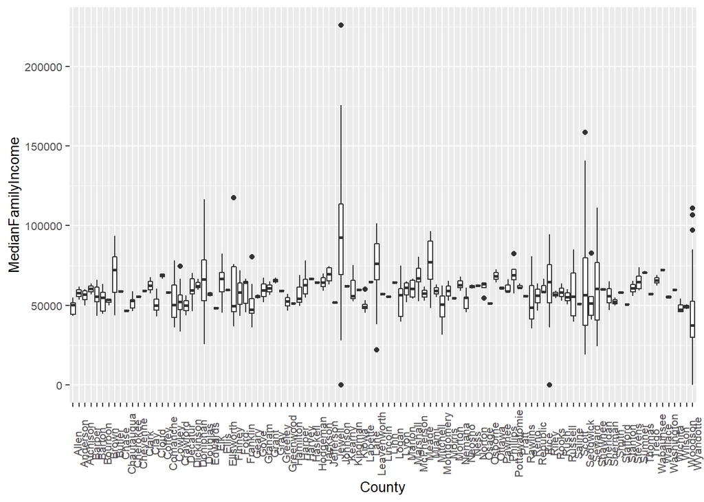

```r
#create the plot
ggplot(Kansas_sub)+
  geom_boxplot(aes(x= County, y= MedianFamilyIncome)) +
  theme(axis.text.x = element_text(angle = 90), text = element_text(size= 10) )
```

```r
#examine the SD to see with county varied the most

Kansas_sub %>%
  group_by(County) %>%
  summarize(SD_MFI = sd(MedianFamilyIncome)) %>%
  arrange(SD_MFI)
```

```
## # A tibble: 105 x 2
##    County     SD_MFI
##    <chr>       <dbl>
##  1 Ellsworth    243.
##  2 Jewell       261.
##  3 Linn         844.
##  4 Sheridan     907.
##  5 Stafford     998.
##  6 Pawnee      1179.
##  7 Thomas      1211.
##  8 Washington  1225.
##  9 Coffey      1606.
## 10 Pratt       1651.
## # ... with 95 more rows
```

## Question 5

**Now check to see how MedianFamilyIncome compares across locations with low (or not) food accessibility (LAhalfand10). Compare using both basic descriptive statistics and graphical representation. What did you find**

I found no obvious difference in medianfamilyincome when examining across all locations. When examining by county, 8 out of 10 of the highest mean medianfamilyincomes did not have low food accessibility. When plotting all of the counties, all of the boxplots overlap suggesting a lack in a significant difference.

```r
#descriptive statistics
Kansas_sub %>%
  group_by(County, LAhalfand10) %>%
  summarize(SD_MFI = sd(MedianFamilyIncome),
            AVG_MFI = mean(MedianFamilyIncome)) %>%
  arrange(desc(AVG_MFI))
```

```
## # A tibble: 161 x 4
## # Groups:   County [105]
##    County      LAhalfand10 SD_MFI AVG_MFI
##    <chr>             <int>  <dbl>   <dbl>
##  1 Johnson               1 35995.  93928.
##  2 Leavenworth           0  9133.  83646.
##  3 Miami                 0 11590.  83076.
##  4 Butler                0 10232.  80421.
##  5 Cowley                0    NA   78182
##  6 Johnson               0 36217.  76749.
##  7 Shawnee               0 13239.  76189.
##  8 Finney                0 40520.  76137
##  9 Lyon                  0    NA   74750
## 10 Wallace               1    NA   72188
## # ... with 151 more rows
```

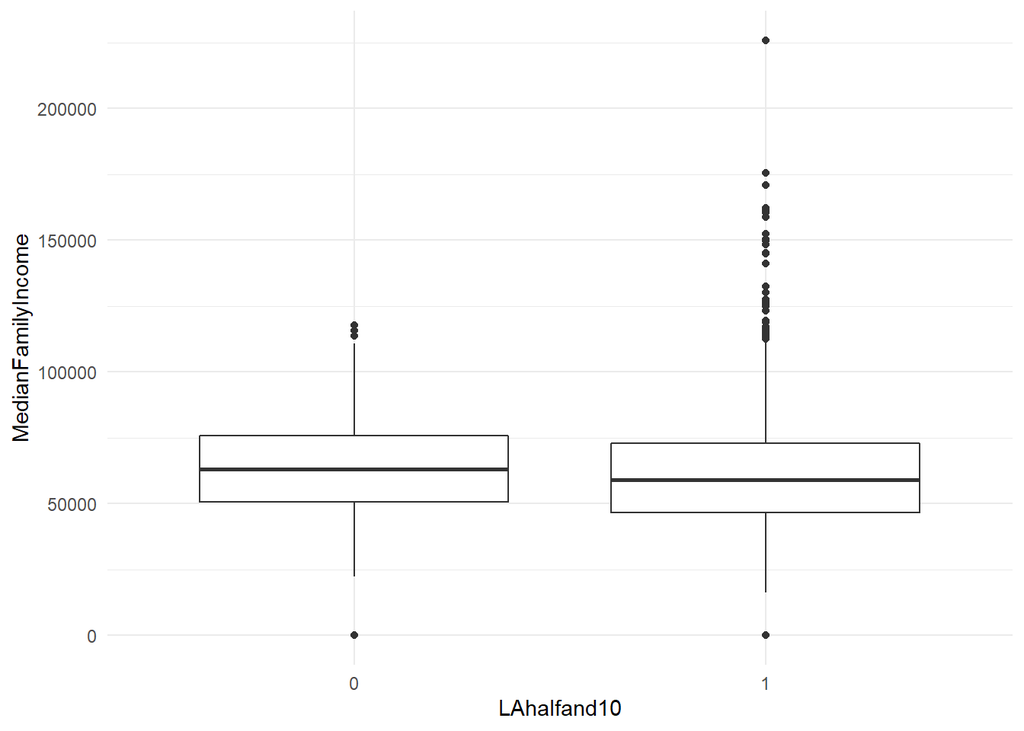

```r
#make LAhalfand10 flag a character instead of an interger
Kansas_sub<-Kansas_sub %>%
  mutate(LAhalfand10 = as.character(LAhalfand10))

#plot all counties combined
ggplot(Kansas_sub)+
  geom_boxplot(aes(x= LAhalfand10, y= MedianFamilyIncome)) +
  theme_minimal ()
```

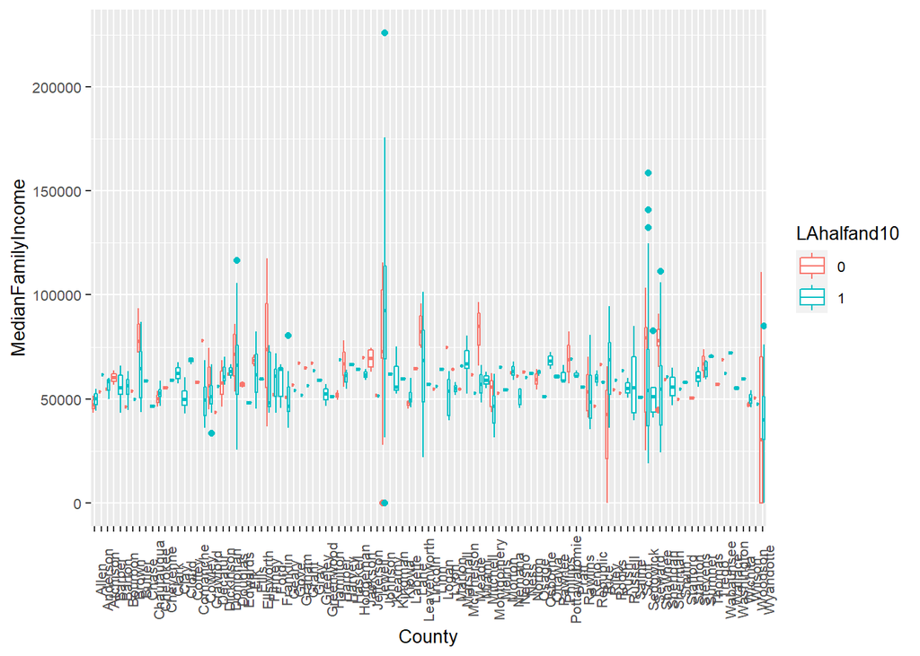

```r
#plot all counties seperate
ggplot(Kansas_sub)+
  geom_boxplot(aes(x= County, y= MedianFamilyIncome, color= LAhalfand10)) +
  theme(axis.text.x = element_text(angle = 90), text = element_text(size= 10))
```

## Question 6

**Choose one other variable in your Kansas data and examine the variations across counties and food accessibility using both descriptive statistics and graphical comparison. What did you find?**

I found somewhat of a difference in TractSNAP when examining across all locations. Low accessibilty to food had a higher average of houses receiving benefits. When examining by county, 7 out of 10 of the highest mean number of households recieving snap benefits had low food accessibility. When plotting all of the counties, all of the boxplots overlap but to a greater degree than the previous variable, medianfamilyincome, suggesting a greater chance of find a significant difference for some counties.

```r
#Summary stats and plot for TractSNAP (count of houses who receive SNAP benefits) and food accessibility
Kansas_sub %>%
  group_by(LAhalfand10) %>%
  summarize(SD_SNAP = sd(TractSNAP),
            AVG_SNAP = mean(TractSNAP)) %>%
  arrange(AVG_SNAP)
```

```
## # A tibble: 2 x 3
##   LAhalfand10 SD_SNAP AVG_SNAP
##   <chr>         <dbl>    <dbl>
## 1 0              90.1     109.
## 2 1             122.      146.
```

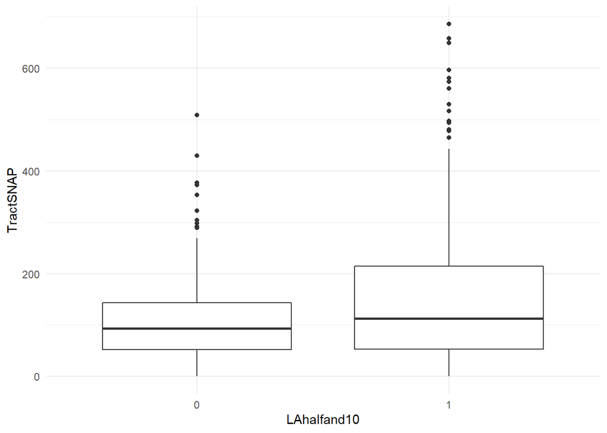

```r
#all counties
ggplot(Kansas_sub)+
  geom_boxplot(aes(x= LAhalfand10, y= TractSNAP)) +
  theme_minimal ()
```

```r
#Summary stats and plot for TractSNAP (count of houses who receive SNAP benefits) by county
Kansas_sub %>%
  group_by(County,LAhalfand10) %>%
  summarize(SD_SNAP = sd(TractSNAP),
            AVG_SNAP = mean(TractSNAP)) %>%
  arrange(desc(AVG_SNAP))
```

```
## # A tibble: 161 x 4
## # Groups:   County [105]
##    County   LAhalfand10 SD_SNAP AVG_SNAP
##    <chr>    <chr>         <dbl>    <dbl>
##  1 Miami    1              80.6     344
##  2 Anderson 0              NA       323
##  3 Bourbon  0              NA       304
##  4 Brown    1              NA       265
##  5 Cherokee 1              83.7     248
##  6 Atchison 1              75.0     247.
##  7 Lyon     1             118.      242.
##  8 Linn     0              NA       240
##  9 Shawnee  1             154.      230.
## 10 Franklin 1              82.5     225.
## # ... with 151 more rows
```

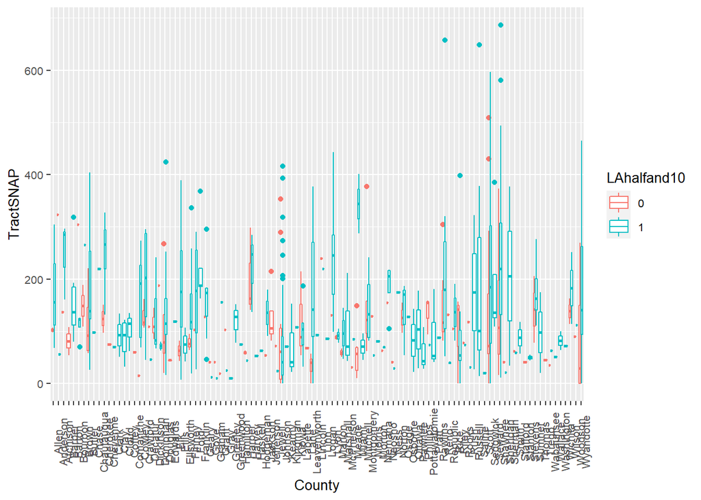

```r
#by counties
ggplot(Kansas_sub)+
  geom_boxplot(aes(x= County, y= TractSNAP, color=LAhalfand10)) +
  theme(axis.text.x = element_text(angle = 90), text = element_text(size= 10) )
```

## Question 7

**Using either descriptive statistics or graphical comparison (or both) examine how the variables in your Kansas dataset relate to food accessibility and food assistance (SNAP). What variables most explain food accessibility and food assistance? (Show your work please.).**

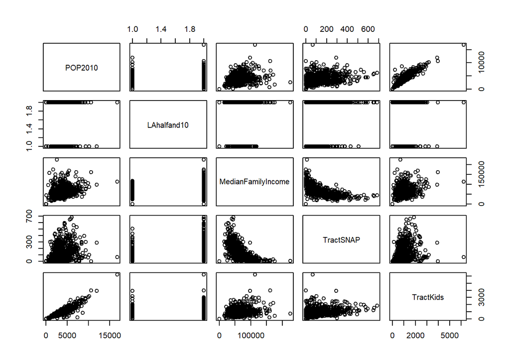

```r
#correlation plot
 plot(Kansas_sub[,c(2,3,4,5,6)])
```

```r
#avg tractsnap and pop by food assistance
Kansas_sub %>%
  group_by(LAhalfand10) %>%
  summarize(SD_SNAP = sd(TractSNAP),
            AVG_SNAP = mean(TractSNAP),
            SD_POP = sd(POP2010),
            AVG_POP = mean(POP2010)) %>%
  arrange(desc(AVG_SNAP))
```

```
## # A tibble: 2 x 5
##   LAhalfand10 SD_SNAP AVG_SNAP SD_POP AVG_POP
##   <chr>         <dbl>    <dbl>  <dbl>   <dbl>
## 1 1             122.      146.  1816.   3801.
## 2 0              90.1     109.  1925.   3369.
```

```r
#avg MFI and pop by food assistance

Kansas_sub %>%
  group_by(LAhalfand10) %>%
  summarize(SD_MFI = sd(MedianFamilyIncome),
            AVG_MFI = mean(MedianFamilyIncome),
            SD_POP = sd(POP2010),
            AVG_POP = mean(POP2010)) %>%
  arrange(desc(AVG_MFI))
```

```
## # A tibble: 2 x 5
##   LAhalfand10 SD_MFI AVG_MFI SD_POP AVG_POP
##   <chr>        <dbl>   <dbl>  <dbl>   <dbl>
## 1 1           28019.  63992.  1816.   3801.
## 2 0           22844.  62653.  1925.   3369.
```

## Question 8

**Use the full national dataset you created in step 1 and create a state-by-state summary of each variable. Use this state summary dataset to examine how food accessibility varies across states (you can choose which measure of food accessibility to use). Which states have the most problems with food accessibility? Which have the lowest?**

Vermont has the lowest average rates of food inaccessibility while Arizona has the highest with Utah having similar high rates.

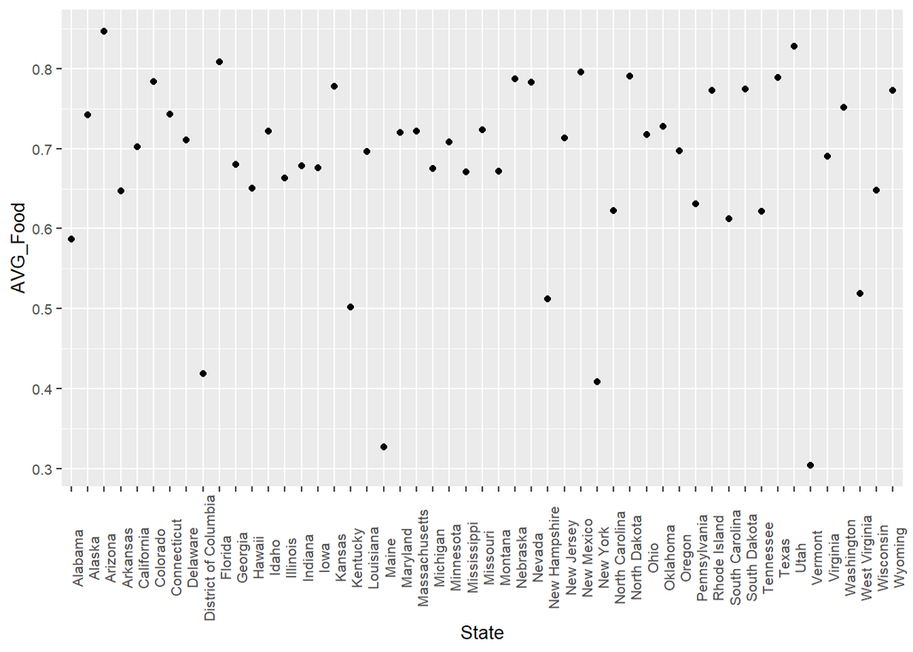

```r
#means for all numeric variables

summary_avg<-Sub_food %>%
  group_by(State) %>%
  summarise_if(is.numeric, mean, na.rm = TRUE)


#average rate of food availability by state
Sub_food %>%
  group_by(State) %>%
  summarize(AVG_Food = mean(LAhalfand10),) %>%
  arrange(desc(AVG_Food)) %>%
  ggplot(.)+
    geom_point(aes(State, AVG_Food)) +
    theme(axis.text.x = element_text(angle = 90), text = element_text(size= 10) )
```

## Question 9

**Examine the trends between 3 variables of your choice and food accessibility across states in the US and describe your findings**

One interesting thing to note from my first graph, is that as the medianfamilyincome increases, poverty becomes more rare. The lower medianfaminlyincomes have higher variability in poverty rates. All thre of my figures seem to have food accessibility on the edges of the distribution, especially some that may have been true outliers. I believe if there is a pattern among these variables, it is unlikely to be linear, demonstrated by the originally plot produced comparing variables against eachother.

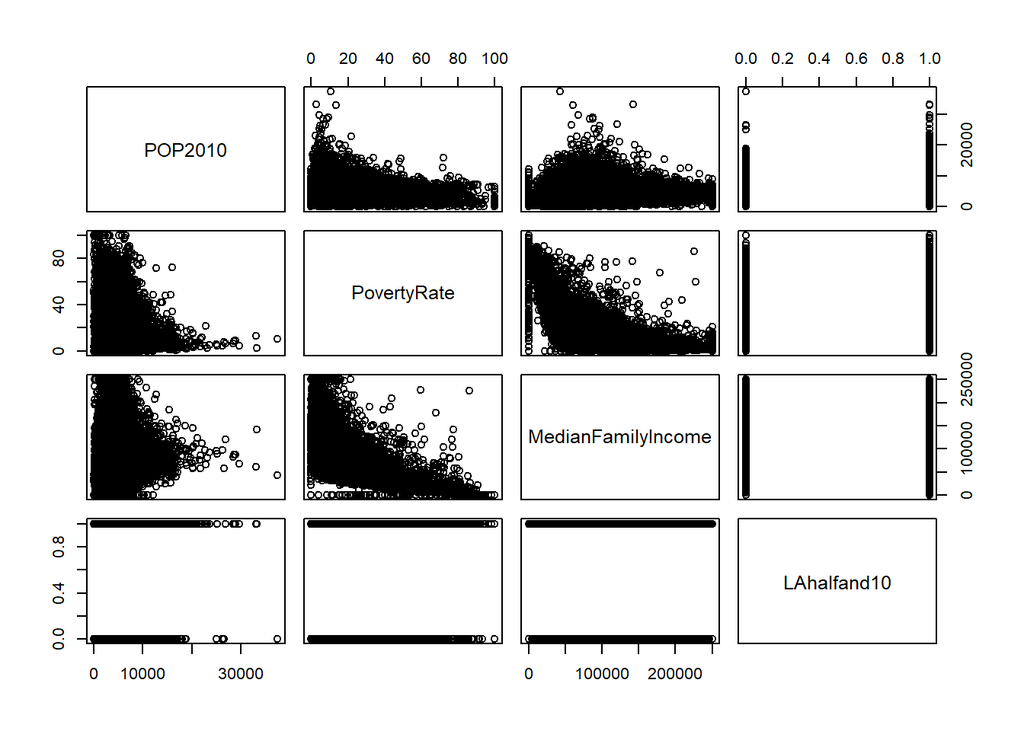

```r
#coorelation plots
plot(Sub_food[,c(5,16,17,19)])
```

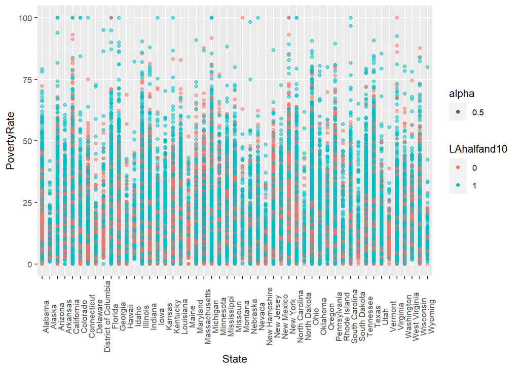

```r
Sub_food<-Sub_food %>%
  mutate(LAhalfand10 = as.character(LAhalfand10))


# scatterplots for comparing my three variables across state and food availability
ggplot(Sub_food)+
  geom_point(aes(x= State, y= PovertyRate, color= LAhalfand10, alpha= 0.5)) +
  theme(axis.text.x = element_text(angle = 90), text = element_text(size= 10) )
```

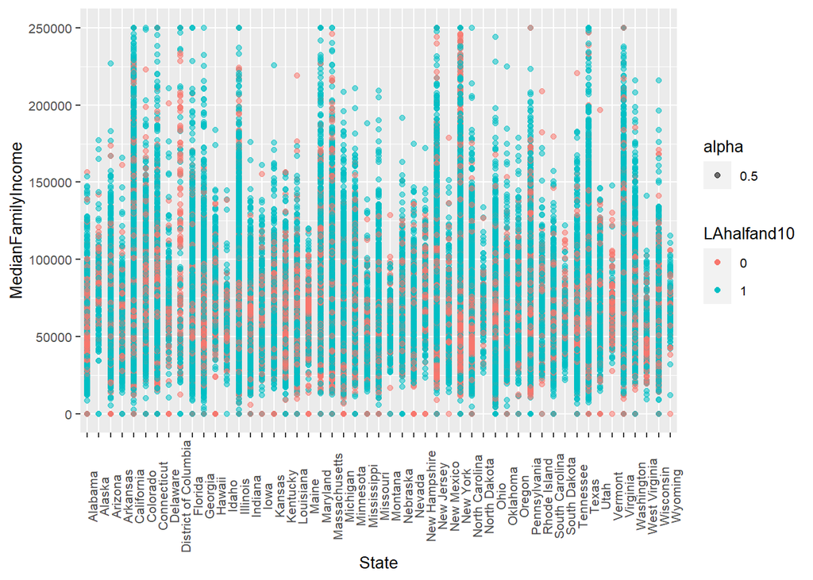

```r
ggplot(Sub_food)+
  geom_point(aes(x= State, y= MedianFamilyIncome, color= LAhalfand10, alpha= 0.5)) +
  theme(axis.text.x = element_text(angle = 90), text = element_text(size= 10) )
```

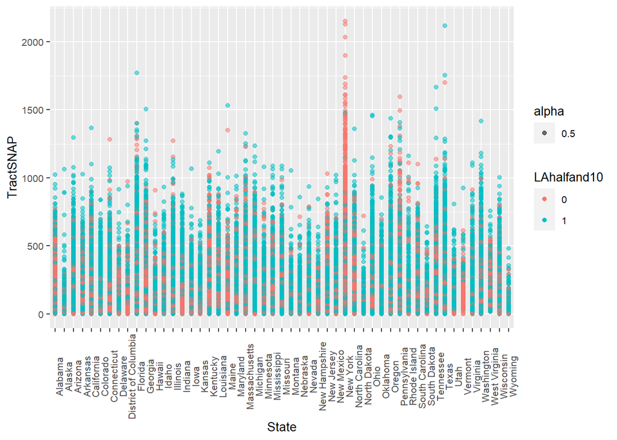

```r
ggplot(Sub_food)+
  geom_point(aes(x= State, y= TractSNAP, color= LAhalfand10, alpha= 0.5)) +
  theme(axis.text.x = element_text(angle = 90), text = element_text(size= 10))
```